# Lab1

Hunter DeVoe

2023-01-23

# Tasks

## Task 1

Obtain the current working directory:

```r
getwd()
```

```
## [1] "C:/Users/Hunter/Desktop/Math 4753 Labs/Lab 1"
```

## Task 2

```r
# Read the DDT data into a dataframe and print the first 6 lines
ddt <- read.csv("DDT-1.csv", header = TRUE)
head(ddt, 6)
```

```
##   RIVER MILE  SPECIES LENGTH WEIGHT DDT
## 1   FCM    5 CCATFISH   42.5    732  10
## 2   FCM    5 CCATFISH   44.0    795  16
## 3   FCM    5 CCATFISH   41.5    547  23
## 4   FCM    5 CCATFISH   39.0    465  21
## 5   FCM    5 CCATFISH   50.5   1252  50
## 6   FCM    5 CCATFISH   52.0   1255 150
```

## Task 3

- What are the qualitative variables in “ddt”?

The qualitative variables in the DDT data file are River and Species

- What are the quantitative variables in “ddt”?

The quantitative variables in the DDT data file are Mile, Length, Weight, and DDT

- How many SPECIES are in the ddt data set?

There are three species in the DDT data file: CCATFISH, SMBUFFALO, and LMBASS

- Subset the ddt data set so that we see only the observations with SPECIES, LMBASS and WEIGHT bigger than 800gms

```r
subset(ddt, SPECIES == "LMBASS" & WEIGHT > 800)
```

```
##     RIVER MILE SPECIES LENGTH WEIGHT DDT
## 141   TRM  345  LMBASS     30    856 2.2
## 144   TRM  345  LMBASS     36   1433 1.9
```

- Subset the ddt data set so that we see only those observations where the RIVER is SCM and DDT bigger than 4.0

```r
subset_df <- NULL
subset_df <- subset(ddt, RIVER == "SCM" & DDT > 4.0)
subset_df
```

```
##    RIVER MILE  SPECIES LENGTH WEIGHT DDT
## 16   SCM    1 CCATFISH     45    984 9.1
## 17   SCM    1 CCATFISH     43    965 7.8
## 18   SCM    1 CCATFISH     45   1084 4.1
```

### Clicker Questions

1. Find the mean length of fish in the ddt data frame

```r
mean(ddt$LENGTH)
```

```
## [1] 42.8125
```

2. What is the standard deviation of the weight of fish in the ddt data frame?

```r
sd(ddt$WEIGHT)
```

```
## [1] 376.5461
```

4. If v = 1:20 what is the last value of v/20?

```r
v = 1:20
v / 20
```

```
##  [1] 0.05 0.10 0.15 0.20 0.25 0.30 0.35 0.40 0.45 0.50 0.55 0.60 0.65 0.70 0.75
## [16] 0.80 0.85 0.90 0.95 1.00
```

So, the last value of v/20 is 1.00

## Task 4

- Make a table of the rivers

```r
table(ddt$RIVER)
```

```
##
## FCM LCM SCM TRM
##   6   6   6 126
```

- Make a color coded barplot of the rivers

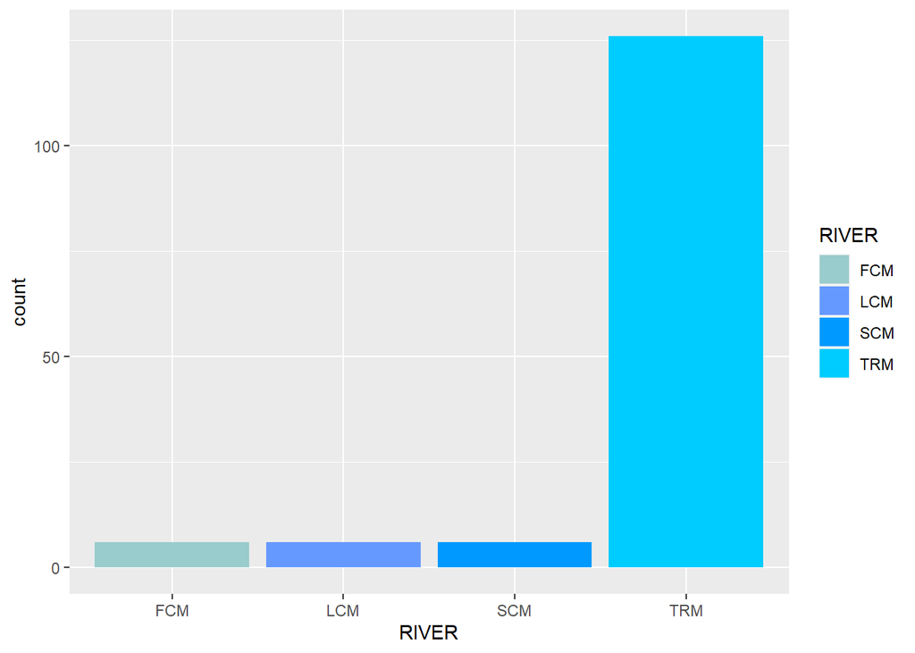

```r
ggplot(ddt, aes(x = RIVER, fill = RIVER)) + geom_bar() + scale_fill_manual(values = c("#99CCCC", "#6699FF", "#0099FF", "#00CCFF"))
```

- Make a table of the rivers crossed with the species of fish

```r
table(ddt$RIVER, ddt$SPECIES)
```

```
##
##       CCATFISH LMBASS SMBUFFALO
##   FCM        6      0         0
##   LCM        6      0         0
##   SCM        6      0         0
##   TRM       78     12        36
```

- Make a barplot of the rivers crossed with the species of fish

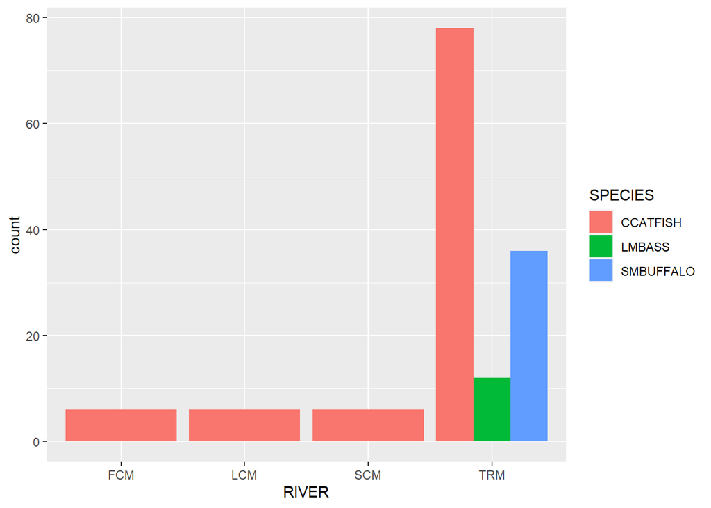

```r
ggplot(ddt, aes(x = RIVER)) + geom_bar(aes(fill = SPECIES), position = "dodge")
```

## Task 5

- Make a pie chart of Fish SPECIES

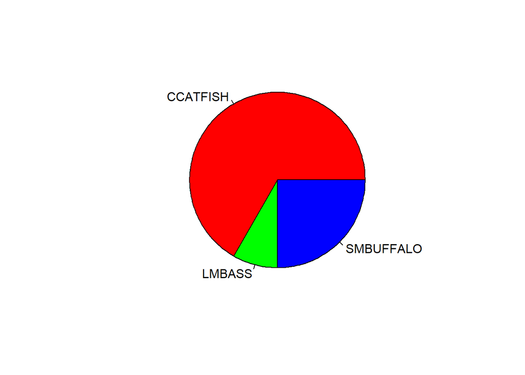

```r
pie(table(ddt$SPECIES), col = rainbow(3))
```

- Make a pie chart of RIVERS

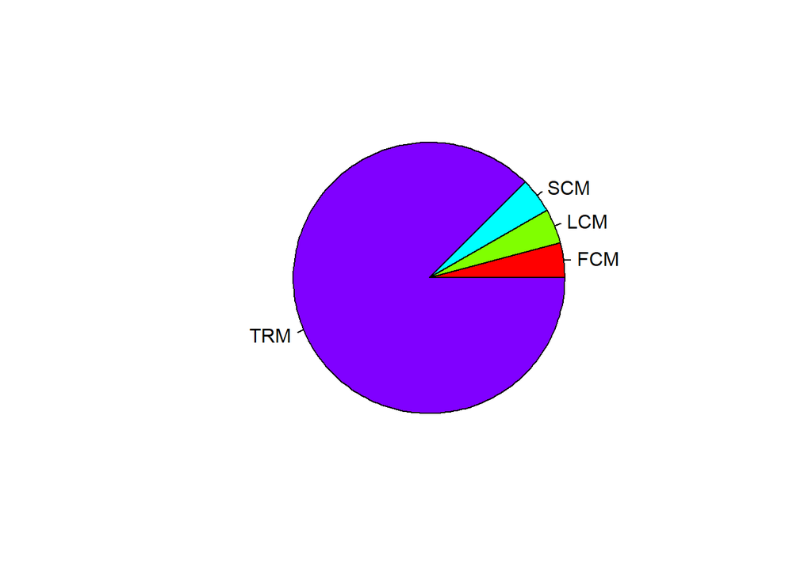

```r
pie(table(ddt$RIVER), col = rainbow(4))
```

## Task 6

- Make a boxplot of the variable DDT

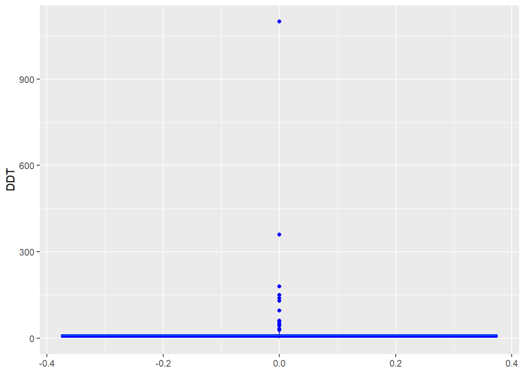

```r
ggplot(data = ddt, aes(y = DDT)) + geom_boxplot(color = "blue", fill = "cyan3")
```

The box plot above includes all of the given data, but we can clearly see a few outliers affecting how the plot looks. I decided to remove the points that are greater than 150. After removing the major outliers, a more comprehensible box plot is produced. Of course, one should be more wary when discarding outliers, but removing them here helps to see the plot a bit better.

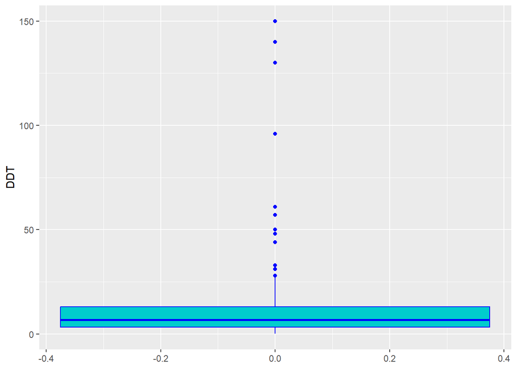

```r
ddtfiltered <- subset(ddt, DDT <= 150)
ggplot(data = ddtfiltered, aes(y = DDT)) + geom_boxplot(color = "blue", fill = "cyan3")
```

- Make a boxplot of the variable WEIGHT (in grams)

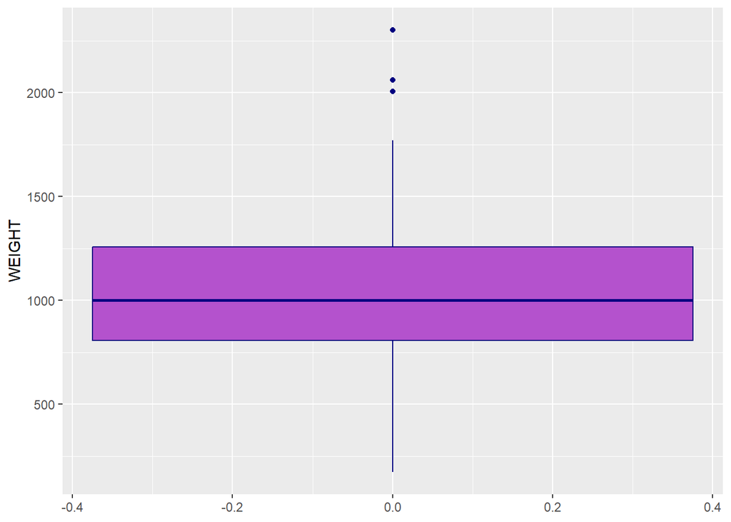

```r
ggplot(data = ddt, aes(y = WEIGHT)) + geom_boxplot(color = "navy", fill = "mediumorchid3")
```

Fortunately for this data set, the outliers do not significantly affect how the plot is generated

- Make a boxplot of the variable LENGTH (in centimeters)

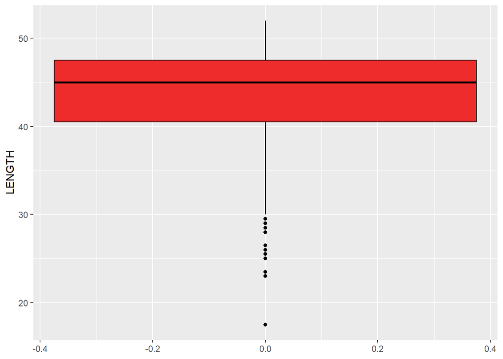

```r
ggplot(data = ddt, aes(y = LENGTH)) + geom_boxplot(color = "black", fill = "firebrick2")
```

## Task 7

- Make a coplot of LENGTH Vs WEIGHT given RIVER

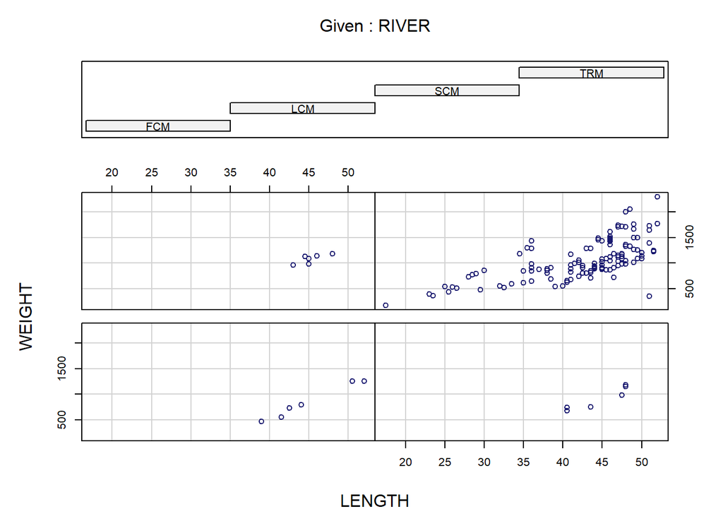

```r
coplot(WEIGHT ~ LENGTH|RIVER, data = ddt, col = "midnightblue")
```

- Make a coplot of DDT Vs WEIGHT given SPECIES

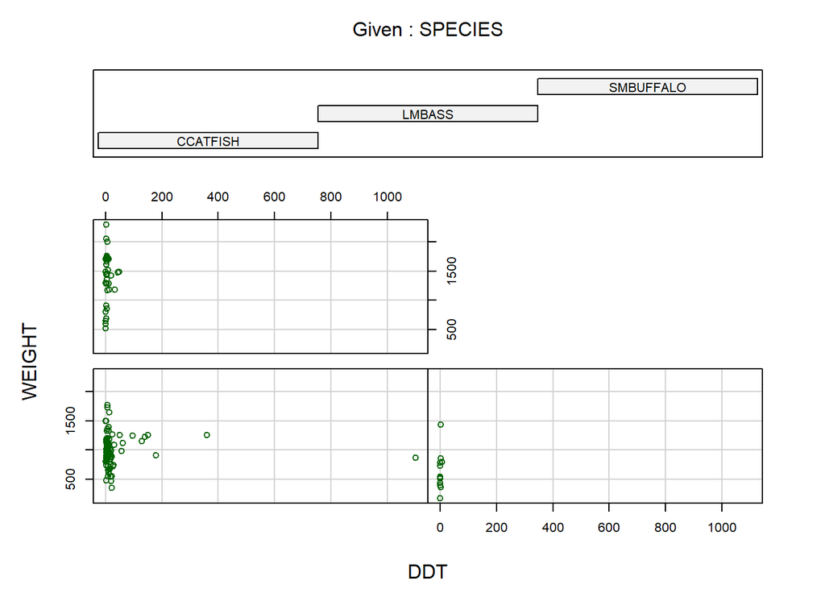

```r
coplot(WEIGHT ~ DDT|SPECIES, data = ddt, col = "darkgreen")
```

## Task 8

- Use ggplot and make the following boxplots (be sure to put your name on the title using ggtitle())

Plot 1

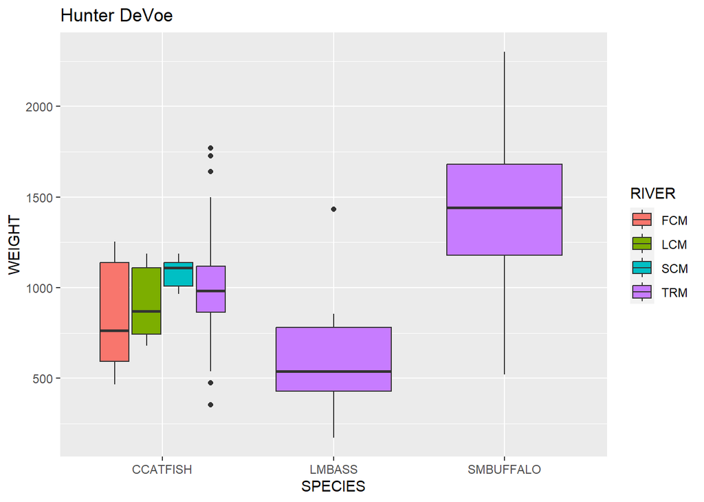

```r
ggplot(data = ddt, aes(x = SPECIES, y = WEIGHT)) + geom_boxplot() + aes(fill = RIVER) + ggtitle("Hunter DeVoe")
```

- Use ggplot and make the following violin plots (name on the title)

Plot 2

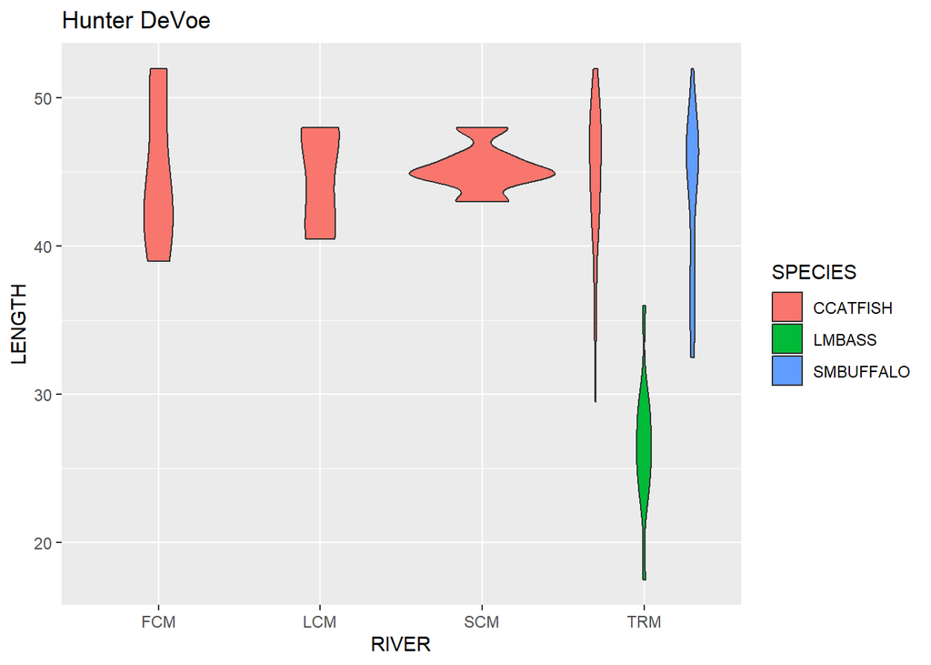

```r
ggplot(data = ddt, aes(x = RIVER, y = LENGTH)) + geom_violin() + aes(fill = SPECIES) + ggtitle("Hunter DeVoe")
```

- Use ggplot and make the following scatter plots (name on the title)

Plot 3

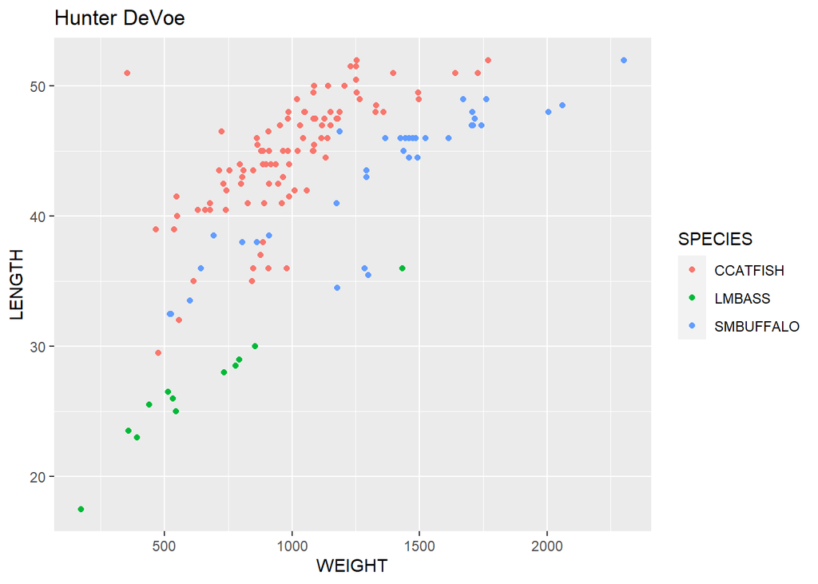

```r
ggplot(ddt, aes(x=WEIGHT, y=LENGTH, fill = SPECIES, col = SPECIES)) + geom_point() + ggtitle("Hunter DeVoe")
```

```r
# CLEAN UP #################################################

# Clear environment
rm(list = ls())

# Clear packages
p_unload(all)  # Remove all add-ons
```

```
## The following packages have been unloaded:
## forcats, stringr, dplyr, purrr, readr, tidyr, tibble, ggplot2, tidyverse, pacman
```

```r
# Clear plots
dev.off()  # But only if there IS a plot
```

```r
# Clear console
cat("\014")  # ctrl+L
```

```r
# Clear mind :)
```